# Battle of the Neighborhoods: Chicago Pet Store

#### Coursera Applied Data Science Capstone Assignment

# Introduction

A client is looking for the perfect location to open a new pet store in Chicago, IL. We will help out client narrow their search by identifying neighborhoods that are similar to the neighborhoods that already have pet stores as these may offer ideal locations for a new pet store.

To accomplish this goal, I will use the Foursquare API to download venue data for each neighborhood in Chicago and then cluster the neighborhood data using k-means. Neighborhoods within the same cluster as those with existing pet stores could provide the best location for a new pet store.

# Data

### Chicago Neighborhoods

Chicago neighborhood names and boundary data can be downloaded from the Chicago city website (https://data.cityofchicago.org/resource/igwz-8jzy.json). The boundaries information is provided as a multipolygon with multiple latitude and longitude points for each neighborhood. A centroid point can be calculated from the boundary points and the latitude and longitude of the centroid point can be used as the location for the neighborhood in the Foursquare API query.

First, download the data from the city of Chicago website:

```python
import numpy as np
import pandas as pd
import urllib, json

with urllib.request.urlopen("https://data.cityofchicago.org/resource/igwz-8jzy.json") as url:
    data = json.loads(url.read())

neighborhoods = pd.DataFrame.from_records(data)

# Drop unnecessary columns
neighborhoods.drop(['area', 'area_num_1', 'area_numbe', 'comarea', 'comarea_id', 'perimeter',
                   'shape_area', 'shape_len'], inplace=True, axis=1)
neighborhoods.head()
```

|  | community | the_geom |
| --- | --- | --- |
| 0 | DOUGLAS | {'type': 'MultiPolygon', 'coordinates': [[[[-8... |
| 1 | OAKLAND | {'type': 'MultiPolygon', 'coordinates': [[[[-8... |
| 2 | FULLER PARK | {'type': 'MultiPolygon', 'coordinates': [[[[-8... |
| 3 | GRAND BOULEVARD | {'type': 'MultiPolygon', 'coordinates': [[[[-8... |
| 4 | KENWOOD | {'type': 'MultiPolygon', 'coordinates': [[[[-8... |

Next, find the centroid of each neighborhood:

```python
def calculateCentroid(data):

    x, y = zip(*data[0]['coordinates'][0][0])
    lat = sum(x) / len(x)
    lng = sum(y) / len(y)
    return(lat, lng)

centroid = neighborhoods[["the_geom"]].apply(calculateCentroid, axis=1, result_type='expand')

neighborhoods["lng"] = centroid[0]
neighborhoods["lat"] = centroid[1]

neighborhoods.drop(["the_geom"], axis=1, inplace=True)

neighborhoods.head()
```

|  | community | lng | lat |
| --- | --- | --- | --- |
| 0 | DOUGLAS | -87.616148 | 41.836210 |
| 1 | OAKLAND | -87.600263 | 41.822268 |
| 2 | FULLER PARK | -87.632251 | 41.809542 |
| 3 | GRAND BOULEVARD | -87.619113 | 41.812351 |
| 4 | KENWOOD | -87.590145 | 41.809096 |

### Use Foursquare API to explore neighborhoods

The Foursquare API explore venues query returns venue names, locations, and categories for venues within a certain radius of a given location. Venues are grouped into categories such as Pet Shop, Sandwich Place, Park, Bus Station, Bakery, and Mexican Restaurant. For example, the store “Family Dollar” is in the category “Discount Store” and “Subway” is in the “Sandwich Place” category.

```
A total of 3737 venues were downloaded using the Foursquare API.
```

The results look like this:

```python
chicago_venues.head()
```

|  | Neighborhood | Neighborhood Latitude | Neighborhood Longitude | Venue | Venue Latitude | Venue Longitude | Venue Category |
| --- | --- | --- | --- | --- | --- | --- | --- |
| 0 | DOUGLAS | 41.83621 | -87.616148 | Yassa African Restaurant | 41.830780 | -87.616906 | African Restaurant |
| 1 | DOUGLAS | 41.83621 | -87.616148 | Illinois Eye Institute | 41.835265 | -87.622279 | Eye Doctor |
| 2 | DOUGLAS | 41.83621 | -87.616148 | Huetiful Salon | 41.832031 | -87.617668 | Salon / Barbershop |
| 3 | DOUGLAS | 41.83621 | -87.616148 | LA Fitness | 41.832001 | -87.614865 | Gym / Fitness Center |
| 4 | DOUGLAS | 41.83621 | -87.616148 | 31st Street Beach | 41.839458 | -87.608028 | Beach |

How many pet stores are in chicago and where are they located?

```python
pet_store_neighborhood = chicago_venues[chicago_venues['Venue Category']=='Pet Store']['Neighborhood'].tolist()
chicago_venues[chicago_venues['Venue Category']=='Pet Store']
```

|  | Neighborhood | Neighborhood Latitude | Neighborhood Longitude | Venue | Venue Latitude | Venue Longitude | Venue Category |
| --- | --- | --- | --- | --- | --- | --- | --- |
| 249 | LINCOLN SQUARE | 41.974304 | -87.694233 | Ruff Haus Pets | 41.966312 | -87.693838 | Pet Store |
| 281 | LINCOLN SQUARE | 41.974304 | -87.694233 | The Active Pet | 41.980764 | -87.692558 | Pet Store |
| 375 | HYDE PARK | 41.794078 | -87.584535 | Parker's Pet Spa & Boutique | 41.795226 | -87.593185 | Pet Store |
| 476 | ROGERS PARK | 42.011938 | -87.665677 | Bark Place | 42.010080 | -87.675223 | Pet Store |
| 482 | ROGERS PARK | 42.011938 | -87.665677 | Rogers Bark | 42.015890 | -87.668157 | Pet Store |
| 540 | ROGERS PARK | 42.011938 | -87.665677 | Bentley's Corner Barkery | 42.012828 | -87.674643 | Pet Store |
| 711 | ALBANY PARK | 41.969366 | -87.718181 | Petco | 41.969297 | -87.728584 | Pet Store |
| 803 | PORTAGE PARK | 41.956645 | -87.768717 | Bark Out Loud | 41.953567 | -87.758530 | Pet Store |
| 887 | IRVING PARK | 41.954341 | -87.716141 | Pet Supplies Plus N. Elston | 41.947214 | -87.710269 | Pet Store |
| 956 | DUNNING | 41.947155 | -87.810773 | Ocean Design Aquarium | 41.945306 | -87.816107 | Pet Store |
| 1088 | WEST RIDGE | 41.999314 | -87.697159 | Petco | 41.994880 | -87.690077 | Pet Store |
| 1471 | WEST TOWN | 41.901089 | -87.672629 | Doggy Style Pet Shop | 41.903182 | -87.678284 | Pet Store |
| 2068 | NORWOOD PARK | 41.983951 | -87.804221 | Pet Supplies Plus Chicago | 41.975820 | -87.808093 | Pet Store |
| 2716 | HEGEWISCH | 41.661291 | -87.550494 | 7 Seas Pet Care Center | 41.653243 | -87.545564 | Pet Store |
| 2774 | ARCHER HEIGHTS | 41.808978 | -87.726041 | PetSmart | 41.816968 | -87.725525 | Pet Store |
| 2826 | BRIDGEPORT | 41.835945 | -87.645461 | Bark N' Bites | 41.830842 | -87.643930 | Pet Store |
| 3400 | BEVERLY | 41.712612 | -87.679788 | Petco | 41.717694 | -87.682284 | Pet Store |
| 3502 | MOUNT GREENWOOD | 41.695989 | -87.713143 | Midwest Canine Choppers (GROOMERS) | 41.691744 | -87.703726 | Pet Store |

### Venue frequency

Let's take a closer look at the data. The most venues a neighborhood can have is 100 because we set a limit on the FourSquare request but some of the neighborhoods have very few venues (far right):

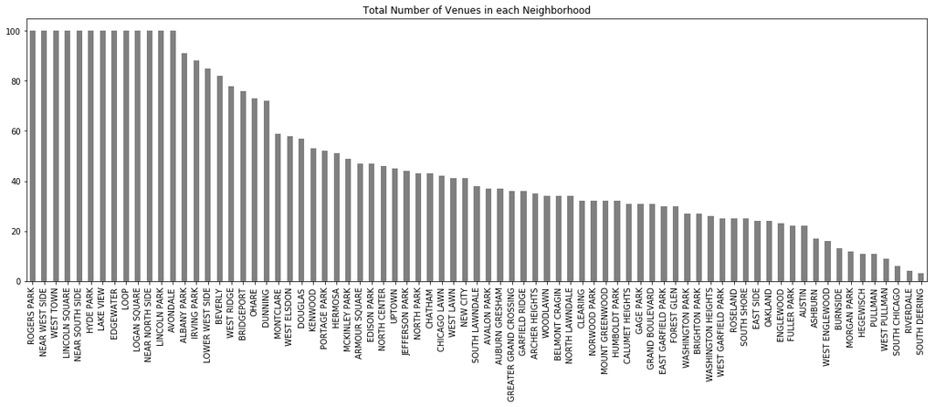

And many venues occur only one time. These venues are not very informative and we will remove them later.

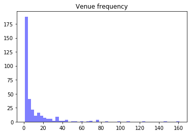

What are the ten most common venues?

```
chicago_venues['Venue Category'].value_counts()[:10]
```

```
Mexican Restaurant      161
Park                    147
Pizza Place             125
Sandwich Place          109
Fast Food Restaurant     97
Bar                      85
Grocery Store            76
Coffee Shop              76
Chinese Restaurant       75
Discount Store           70
Name: Venue Category, dtype: int64
```

Methodology

Before beginning analysis I will first preprocess the data and remove neighborhoods with very few venues as well as venues that occur only rarely.

Once the data is filtered, we can calculate the mean occurance of the venues in each neighborhood. Since the data is still very sparse, we can use PCA to reduce the dimensionality. Then we use the reduced dataset to cluster the neighborhoods using k-means clustering. The number of clusters is determined using the silhouette score and plots to visualize the seperation of the clusters.

After the neighborhoods are clustered, we can identify the neighborhoods that are in the same cluster or are simialr to the neighborhoods with existing pet stores. The neighborhoods that are similar to those that already have a pet store are the best neighborhoods for a new pet store.

Preprocessing

Remove neighborhoods with less than ten venues.

```
# Neighborhoods with 10 or fewer venues
x = chicago_venues['Neighborhood'].value_counts()
less10 = x[x < 10]
less10
```

```
WEST PULLMAN     9
SOUTH CHICAGO    6
RIVERDALE        4
SOUTH DEERING    3
Name: Neighborhood, dtype: int64
```

```
# Remove neighborhoods with less than ten
threshold = 10
value_counts = chicago_venues[['Neighborhood']].stack().value_counts() # Entire DataFrame
to_remove = value_counts[value_counts < threshold].index.tolist()

chicago_venues.drop(chicago_venues[chicago_venues.Neighborhood.isin(to_remove)].index.tolist(), inplace=True)

print("The following venues were removed: {}".format(to_remove))
```

```
The following venues were removed: ['WEST PULLMAN', 'SOUTH CHICAGO', 'RIVERDALE', 'SOUTH DEERING']
```

Remove venues occuring less than five times.

```
# one hot encoding
chicago_onehot = pd.get_dummies(chicago_venues[['Venue Category']], prefix="", prefix_sep="")

# Remove venues that occur less than ten times
chicago_onehot.drop([col for col, val in chicago_onehot.sum().iteritems() if val < 5], axis=1, inplace=True)
```

Calculate the mean occurance of a venue in each neighborhood.

The table below shows the mean frequeny of each venue category in a few of the neighborhoods. This data will be later reduced using PCA.

|  | Neighborhood | Accessories Store | American Restaurant | Aquarium | Arcade | Art Gallery | Arts & Crafts Store | Asian Restaurant | Athletics & Sports | Automotive Shop | ... | Vegetarian / Vegan Restaurant | Video Game Store | Video Store | Vietnamese Restaurant | Wine Bar | Wine Shop | Wings Joint | Women's Store | Yoga Studio | Zoo Exhibit |
| --- | --- | --- | --- | --- | --- | --- | --- | --- | --- | --- | --- | --- | --- | --- | --- | --- | --- | --- | --- | --- | --- |
| 0 | ALBANY PARK | 0.010989 | 0.010989 | 0.0 | 0.0 | 0.0 | 0.000000 | 0.032967 | 0.0 | 0.0 | ... | 0.0 | 0.0 | 0.000000 | 0.010989 | 0.0 | 0.0 | 0.000000 | 0.0 | 0.0 | 0.0 |
| 1 | ARCHER HEIGHTS | 0.000000 | 0.000000 | 0.0 | 0.0 | 0.0 | 0.028571 | 0.000000 | 0.0 | 0.0 | ... | 0.0 | 0.0 | 0.028571 | 0.000000 | 0.0 | 0.0 | 0.028571 | 0.0 | 0.0 | 0.0 |
| 2 | ARMOUR SQUARE | 0.000000 | 0.021277 | 0.0 | 0.0 | 0.0 | 0.000000 | 0.021277 | 0.0 | 0.0 | ... | 0.0 | 0.0 | 0.000000 | 0.000000 | 0.0 | 0.0 | 0.000000 | 0.0 | 0.0 | 0.0 |
| 3 | ASHBURN | 0.000000 | 0.058824 | 0.0 | 0.0 | 0.0 | 0.000000 | 0.000000 | 0.0 | 0.0 | ... | 0.0 | 0.0 | 0.000000 | 0.000000 | 0.0 | 0.0 | 0.000000 | 0.0 | 0.0 | 0.0 |
| 4 | AUBURN GRESHAM | 0.000000 | 0.027027 | 0.0 | 0.0 | 0.0 | 0.000000 | 0.000000 | 0.0 | 0.0 | ... | 0.0 | 0.0 | 0.027027 | 0.000000 | 0.0 | 0.0 | 0.000000 | 0.0 | 0.0 | 0.0 |

5 rows × 152 columns

What are the top 10 venues for each neighborhood?

|  | Neighborhood | 1st Most Common Venue | 2nd Most Common Venue | 3rd Most Common Venue | 4th Most Common Venue | 5th Most Common Venue | 6th Most Common Venue | 7th Most Common Venue | 8th Most Common Venue | 9th Most Common Venue | 10th Most Common Venue |
| --- | --- | --- | --- | --- | --- | --- | --- | --- | --- | --- | --- |
| 0 | ALBANY PARK | Pizza Place | Mexican Restaurant | Chinese Restaurant | Coffee Shop | Hookah Bar | Ice Cream Shop | Bakery | Grocery Store | Discount Store | Sandwich Place |
| 1 | ARCHER HEIGHTS | Mexican Restaurant | Bank | Seafood Restaurant | Sandwich Place | Grocery Store | Mobile Phone Shop | Pet Store | Cosmetics Shop | Park | Food |
| 2 | ARMOUR SQUARE | Chinese Restaurant | Pizza Place | Bar | Park | Mexican Restaurant | Restaurant | Italian Restaurant | Karaoke Bar | Asian Restaurant | New American Restaurant |
| 3 | ASHBURN | Park | Pizza Place | BBQ Joint | Chinese Restaurant | Clothing Store | Shoe Store | Seafood Restaurant | Liquor Store | Cosmetics Shop | Bank |
| 4 | AUBURN GRESHAM | Fast Food Restaurant | Pharmacy | Park | Lounge | Southern / Soul Food Restaurant | Discount Store | Grocery Store | Donut Shop | Currency Exchange | Seafood Restaurant |

### Cluster Neighborhoods

Use PCA to reduce dimensions. The look at both inertia and silhouette score to determine the best number of cluster. Cluster using kmeans.

```python
from sklearn.decomposition import PCA
from sklearn.metrics import silhouette_score
from sklearn.metrics import silhouette_samples

data = chicago_grouped.drop('Neighborhood', 1)

reduced_data = PCA(n_components=2).fit_transform(data)
```

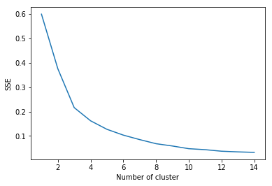

```python
# Find optimal number of k
from sklearn.cluster import KMeans

sse = {}
for k in range(1, 15):
    kmeans = KMeans(n_clusters=k, max_iter=1000).fit(reduced_data)
    sse[k] = kmeans.inertia_ # Inertia: Sum of distances of samples to their closest cluster center

plt.figure()
plt.plot(list(sse.keys()), list(sse.values()))
plt.xlabel("Number of cluster")
plt.ylabel("SSE")
plt.show()
```

Scikit-learn has an excellent tutorial on silhouette analysis. I used their code here with some minor changes to fit the data. Here's the link:

https://scikit-learn.org/stable/auto_examples/cluster/plot_kmeans_silhouette_analysis.html

```
For n_clusters = 3 The average silhouette_score is : 0.46973889199563196
For n_clusters = 4 The average silhouette_score is : 0.40272561353517755
For n_clusters = 5 The average silhouette_score is : 0.4190598860925328
For n_clusters = 6 The average silhouette_score is : 0.37661782041767444
For n_clusters = 8 The average silhouette_score is : 0.3741745704449549
```

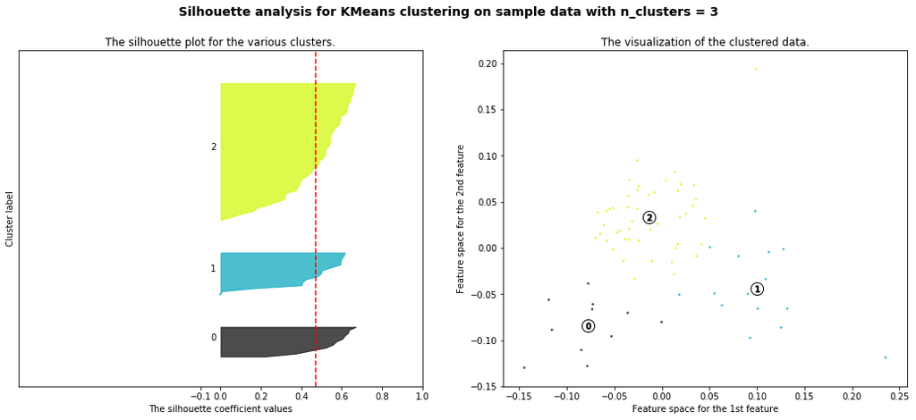

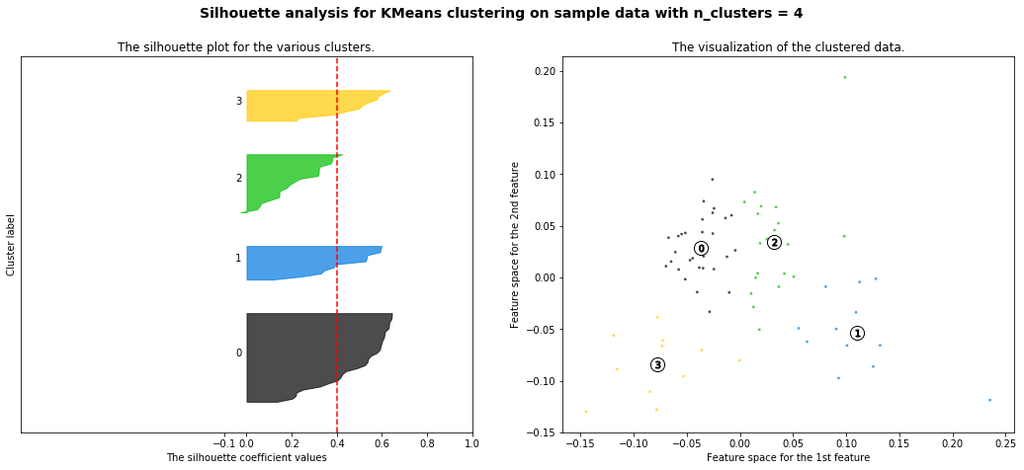

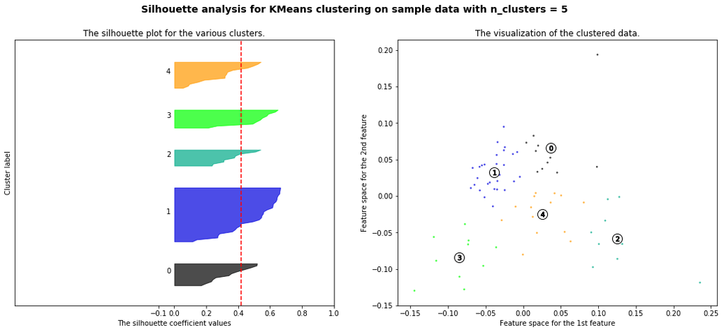

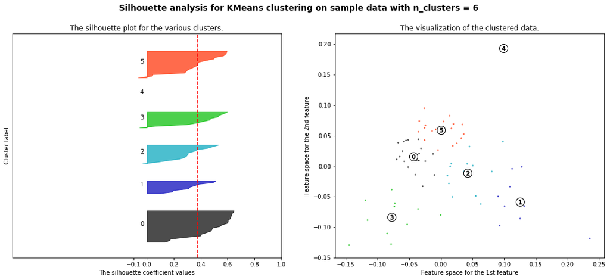

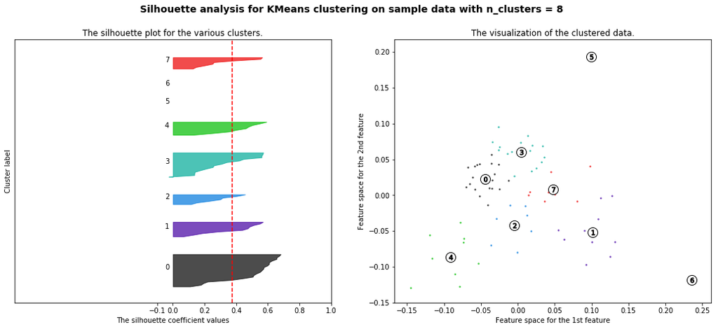

By the scree plot above and the silhouette score here, k=3 clusters is best. However, a lot of the data in cluster 2 is below the red line. I'd rather not have a 'catch-all' cluster. The second best score is 5. We will choose k=5.

```python
kclusters=5

kmeans = KMeans(init='k-means++', n_clusters=kclusters, n_init=10)
kmeans.fit(reduced_data)

# add clustering labels
neighborhoods_venues_sorted.insert(0, 'Cluster Labels', kmeans.labels_)

# merge toronto_grouped with toronto_data to add latitude/longitude for each neighborhood
chicago_merged = neighborhoods_venues_sorted.join(chicago_data.set_index('community'), on='Neighborhood')
```

# Results

## Visualize clusters

```
The geograpical coordinate of Chicago are 41.8755616, -87.6244212.
```

[interactive chart not shown]

In the map above, cluster 0 is red, cluster 1 is purple, cluster 2 is blue, and cluster 3 is light green, and cluster 4 is orange.

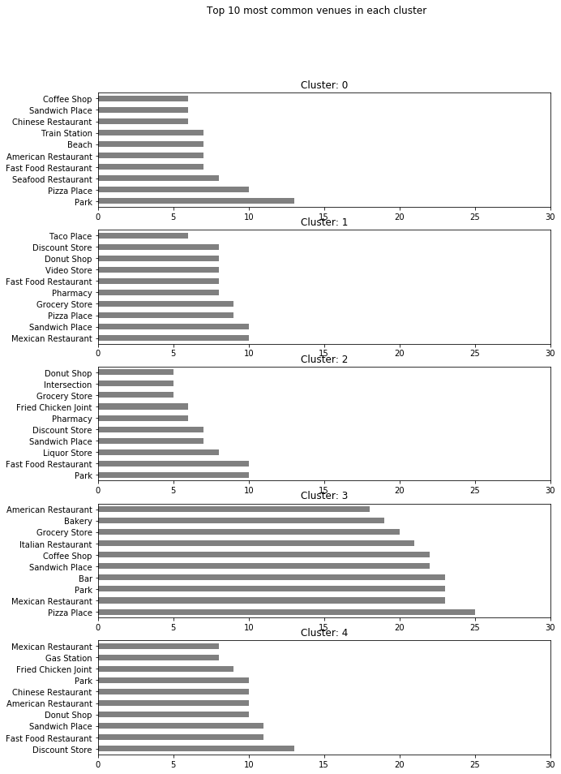

### Find the clusters with pet stores:

Rogers Park had three pet stores. What cluster is Rogers Park in?

```python
chicago_merged.loc[chicago_merged['Neighborhood'] == "ROGERS PARK",]
```

|  | Cluster Labels | Neighborhood | 1st Most Common Venue | 2nd Most Common Venue | 3rd Most Common Venue | 4th Most Common Venue | 5th Most Common Venue | 6th Most Common Venue | 7th Most Common Venue | 8th Most Common Venue | 9th Most Common Venue | 10th Most Common Venue | lng | lat |
| --- | --- | --- | --- | --- | --- | --- | --- | --- | --- | --- | --- | --- | --- | --- |
| 59 | 3 | ROGERS PARK | Mexican Restaurant | Park | Pizza Place | Beach | Bar | Sandwich Place | Bakery | Chinese Restaurant | Coffee Shop | Convenience Store | -87.665677 | 42.011938 |

How many pet stores are in each cluster?

```
3    11
0     2
4     1
1     1
Name: Cluster Labels, dtype: int64
```

There are 11 neighborhoods with pet shops in cluster 3. Which neighborhoods in cluster 3 don't have a pet store?

|  | Cluster Labels | Neighborhood |
| --- | --- | --- |
| 2 | 3 | ARMOUR SQUARE |
| 7 | 3 | AVONDALE |
| 21 | 3 | EDGEWATER |
| 22 | 3 | EDISON PARK |
| 24 | 3 | FOREST GLEN |
| 35 | 3 | JEFFERSON PARK |
| 37 | 3 | LAKE VIEW |
| 38 | 3 | LINCOLN PARK |
| 40 | 3 | LOGAN SQUARE |
| 41 | 3 | LOOP |
| 47 | 3 | NEAR NORTH SIDE |
| 49 | 3 | NEAR WEST SIDE |
| 51 | 3 | NORTH CENTER |
| 53 | 3 | NORTH PARK |
| 56 | 3 | OHARE |

# Discussion

Chicago is known for its deep dish pizza and its magnificant parks nestled between skyscrappers and Lake Michigan so it is no suprise that pizza place and park are the two most common in the cluster 0 since its mostly near the shoreline and in areas that are popular with tourists. Most of the pet shops are in cluster 3.

One limitation of this analysis is that the k-means results were quite varied depending on the preprocessing approach. Without reducing dimensions using PCA, the majority of results all clustered together. It would be interesting to try a method that incorporates features selection, such as a boosted tree.

In addition, there may also be a better was to link the venues to their respective neighborhoods. In this analysis, I downloaded all venues within a certain radius of the neighborhood centroid point. However; this technique is not exact as some neighborhoods are more dense and some are more spread out. If you choose a radius that it too large means, you may end up with duplicated venues from overlapping results, but if you select a radius that is too small, you will not download all the venues for neighborhoods that are more spread out. A better technique might be to use a large radius from the Chicago latitude and longitude and then assign results to neighborhoods based on latitude and longitude data. This would have been possible with the boundary data provided in the Chicago data.

# Conclusion

The best neighborhood for a new pet store is one of the neighborhoods in cluster 3. These are most similar neighborhoods that already have pet stores. We would recommend that our client choose a neighborhood in cluster 3 that does not already have a pet store.